# IODS course project

Rigbe G. Weldatsadik

# Open data science course

## Chapter 1: Data Science Tools

*In this course we will be introduced to the various aspects of open data science, including data wrangling and data analysis. In this chaper, the focus will be on the different tools required in this course including R, Rstudio, git etc.*

[MyGithub_link](https://github.com/Rigbe-ods/IODS-project)

## Chapter 2:Regression and model validation

In this chapter we will be working with Linear Regression. We will use Linear regression to model the relationship between a dependent variable(exam points) and 3 independent variables including attitude and various kinds of questions (which are the top 3 correlated variables with our dependent variable).

The dataset we used in this chapter can be found at [JYTOPKYS3](http://www.helsinki.fi/~kvehkala/JYTmooc/JYTOPKYS3-meta.txt).

#### Preparing the dataset for the analysis

The dataset found [here](http://www.helsinki.fi/~kvehkala/JYTmooc/JYTOPKYS3-data.txt) was first preprocessed such that we scaled and combined certain variables such as attitude and question types(deep, surf, strat) and used these new variables together with other existing variables such as gender and age for the ensuing analysis. The following script was used for this purpose.

```r
library(dplyr)

JYTOPKYS3 <- read.table("http://www.helsinki.fi/~kvehkala/JYTmooc/JYTOPKYS3-data.txt", header = T, sep = '\t')

# the data has 183 observation and 60 variables, all of the variables are of data type numeric except gender which is a factor
# we can check these using the str and dim methods
# read. table functions forced gender to be a factor, we can remove that if we want

str(JYTOPKYS3)
```

```
## 'data.frame':    183 obs. of  60 variables:
##  $ Aa      : int  3 2 4 4 3 4 4 3 2 3 ...
##  $ Ab      : int  1 2 1 2 2 2 1 1 1 2 ...
##  $ Ac      : int  2 2 1 3 2 1 2 2 2 1 ...
##  $ Ad      : int  1 2 1 2 1 1 2 1 1 1 ...
##  $ Ae      : int  1 1 1 1 2 1 1 1 1 1 ...
##  $ Af      : int  1 1 1 1 1 1 1 1 1 2 ...
##  $ ST01    : int  4 4 3 3 4 4 5 4 4 4 ...
##  $ SU02    : int  2 2 1 3 2 3 2 2 1 2 ...
##  $ D03     : int  4 4 4 4 5 5 4 4 5 4 ...
##  $ ST04    : int  4 4 4 4 3 4 2 5 5 4 ...
##  $ SU05    : int  2 4 2 3 4 3 2 4 2 4 ...
##  $ D06     : int  4 2 3 4 4 5 3 3 4 4 ...
##  $ D07     : int  4 3 4 4 4 5 4 4 5 4 ...
##  $ SU08    : int  3 4 1 2 3 4 4 2 4 2 ...
```

[output cut: 46 more lines]

```r
dim(JYTOPKYS3)
```

```
## [1] 183  60
```

```r
# here we are combining questions questions in to deep, surf and stra
deep <- c("D03", "D11", "D19", "D27", "D07", "D14", "D22", "D30","D06",  "D15", "D23", "D31")
surf <- c("SU02","SU10","SU18","SU26", "SU05","SU13","SU21","SU29","SU08","SU16","SU24","SU32")
stra <- c("ST01","ST09","ST17","ST25","ST04","ST12","ST20","ST28")

# since the Attitude variable was a combined one,i.e. a sum of 10 questions, here we are scaling it back by dividing by 10
JYTOPKYS3$attitude <- JYTOPKYS3$Attitude / 10

# the same as in the Attitude variable we are scaling the deep, surf and stra combined variables by taking their means
deep_columns <- select(JYTOPKYS3, one_of(deep))
JYTOPKYS3$deep <- rowMeans(deep_columns)

surf_columns <- select(JYTOPKYS3, one_of(surf))
JYTOPKYS3$surf <- rowMeans(surf_columns)

stra_columns <- select(JYTOPKYS3, one_of(stra))
JYTOPKYS3$stra <- rowMeans(stra_columns)

# after the scaling, we will use the scaled variables and also the additional variables gender, age and points  to make a new data frame called d1

vars <- c('gender', 'Age', 'attitude','deep','stra','surf','Points')

d1 <- select(JYTOPKYS3,one_of(vars))

# we are removing rows that have points less than or equal to 0 from d1 and reassigning it ot d1_nonzero
d1_nonzero <- d1[d1$Points > 0,]

# checking the dim of d1_nonzero
dim(d1_nonzero)
```

```
## [1] 166   7
```

```r
# set the working directory
setwd("~/GitHub/IODS-project")

# write dl_nonzero to a file
write.table(d1_nonzero,file = "data/learning2014.csv", sep = "\t")

# read it again to make sure it is written correctly

l2014_test <- read.table("data/learning2014.csv", header = T, sep = "\t")

# check the written file has correct dimensions and so on
str(l2014_test)
```

```
## 'data.frame':    166 obs. of  7 variables:
##  $ gender  : Factor w/ 2 levels "F","M": 1 2 1 2 2 1 2 1 2 1 ...
##  $ Age     : int  53 55 49 53 49 38 50 37 37 42 ...
##  $ attitude: num  3.7 3.1 2.5 3.5 3.7 3.8 3.5 2.9 3.8 2.1 ...
##  $ deep    : num  3.58 2.92 3.5 3.5 3.67 ...
##  $ stra    : num  3.38 2.75 3.62 3.12 3.62 ...
##  $ surf    : num  2.58 3.17 2.25 2.25 2.83 ...
##  $ Points  : int  25 12 24 10 22 21 21 31 24 26 ...
```

```r
head(l2014_test)
```

```
##   gender Age attitude     deep  stra     surf Points
## 1      F  53      3.7 3.583333 3.375 2.583333     25
## 2      M  55      3.1 2.916667 2.750 3.166667     12
## 3      F  49      2.5 3.500000 3.625 2.250000     24
## 4      M  53      3.5 3.500000 3.125 2.250000     10
## 5      M  49      3.7 3.666667 3.625 2.833333     22
## 6      F  38      3.8 4.750000 3.625 2.416667     21
```

#### Linear Regression model

- reading dataset

The dataset prepared above was read for further analysis:

```r
l2014 <- read.table("data/learning2014.csv",header=T, sep="\t")
```

the dimension and structure was checked using the following methods

```r
str(l2014)
```

```
## 'data.frame':    166 obs. of  7 variables:
##  $ gender  : Factor w/ 2 levels "F","M": 1 2 1 2 2 1 2 1 2 1 ...
##  $ Age     : int  53 55 49 53 49 38 50 37 37 42 ...
##  $ attitude: num  3.7 3.1 2.5 3.5 3.7 3.8 3.5 2.9 3.8 2.1 ...
##  $ deep    : num  3.58 2.92 3.5 3.5 3.67 ...
##  $ stra    : num  3.38 2.75 3.62 3.12 3.62 ...
##  $ surf    : num  2.58 3.17 2.25 2.25 2.83 ...
##  $ Points  : int  25 12 24 10 22 21 21 31 24 26 ...
```

```r
dim(l2014)
```

```
## [1] 166   7
```

166 observations and 7 variables were selected after the data wrangling. It contains Students’ information such as gender, age and exam points.

- data overview

using head we can check the first few observations and then summarize the variables to see information such as mean age etc

```r
head(l2014)
```

```
##   gender Age attitude     deep  stra     surf Points
## 1      F  53      3.7 3.583333 3.375 2.583333     25
## 2      M  55      3.1 2.916667 2.750 3.166667     12
## 3      F  49      2.5 3.500000 3.625 2.250000     24
## 4      M  53      3.5 3.500000 3.125 2.250000     10
## 5      M  49      3.7 3.666667 3.625 2.833333     22
## 6      F  38      3.8 4.750000 3.625 2.416667     21
```

```r
summary(l2014)
```

```
##  gender       Age           attitude          deep            stra
##  F:110   Min.   :17.00   Min.   :1.400   Min.   :1.583   Min.   :1.250
##  M: 56   1st Qu.:21.00   1st Qu.:2.600   1st Qu.:3.333   1st Qu.:2.625
##          Median :22.00   Median :3.200   Median :3.667   Median :3.188
##          Mean   :25.51   Mean   :3.143   Mean   :3.680   Mean   :3.121
##          3rd Qu.:27.00   3rd Qu.:3.700   3rd Qu.:4.083   3rd Qu.:3.625
##          Max.   :55.00   Max.   :5.000   Max.   :4.917   Max.   :5.000
##       surf           Points
##  Min.   :1.583   Min.   : 7.00
##  1st Qu.:2.417   1st Qu.:19.00
##  Median :2.833   Median :23.00
##  Mean   :2.787   Mean   :22.72
##  3rd Qu.:3.167   3rd Qu.:27.75
##  Max.   :4.333   Max.   :33.00
```

One way to visualize the relationship between variable is using ggpairs(GGally).

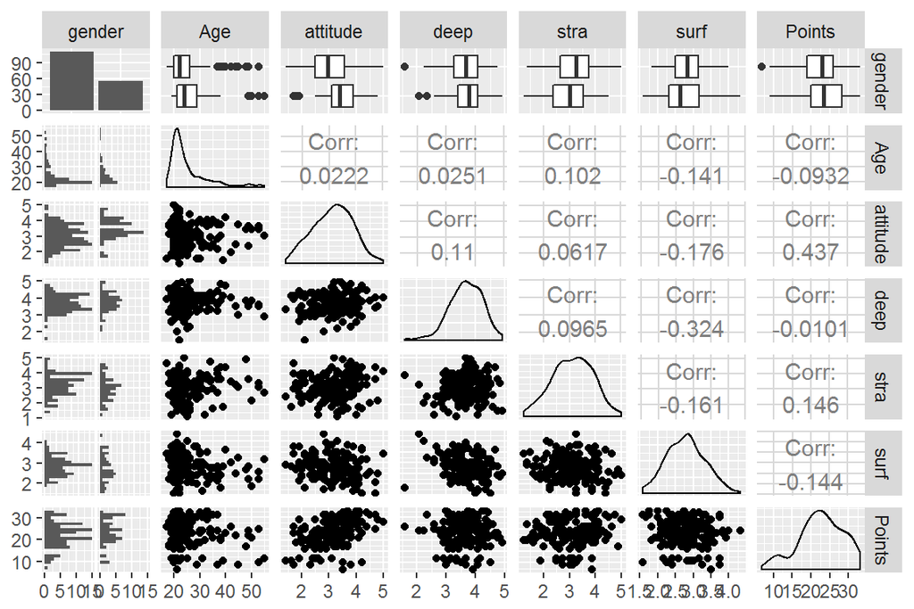

```r
library(GGally)
library(ggplot2)

# create a more advanced plot matrix with ggpairs()
p <- ggpairs(l2014, mapping = aes(), lower = list(combo = wrap("facethist", bins = 20)))
p
```

we can see correlation coefficients exam point variable with other variables from the ggpairs plot. By selecting the top 3 correlated variables which are attitude, stra and surf we can build the regression model to see if there is a relationship between exam points and these variables.

- Linear regression model

```r
point_lm <- lm(Points ~ attitude + stra + surf, data = l2014)
summary(point_lm)
```

```
##
## Call:
## lm(formula = Points ~ attitude + stra + surf, data = l2014)
##
## Residuals:
##      Min       1Q   Median       3Q      Max
## -17.1550  -3.4346   0.5156   3.6401  10.8952
##
## Coefficients:
##             Estimate Std. Error t value Pr(>|t|)
## (Intercept)  11.0171     3.6837   2.991  0.00322 **
## attitude      3.3952     0.5741   5.913 1.93e-08 ***
## stra          0.8531     0.5416   1.575  0.11716
## surf         -0.5861     0.8014  -0.731  0.46563
## ---
## Signif. codes:  0 '***' 0.001 '**' 0.01 '*' 0.05 '.' 0.1 ' ' 1
##
## Residual standard error: 5.296 on 162 degrees of freedom
## Multiple R-squared:  0.2074, Adjusted R-squared:  0.1927
## F-statistic: 14.13 on 3 and 162 DF,  p-value: 3.156e-08
```

The intercept and coefficient for attitude were estimated to be 11.0 and 3.39 respectively. Attitude had a statistically significant relationship with the target variable while the remaining two variables didn’t show a statistically significant relationship. Therefore we modify the model such that only attitude is used to explain exam points.

```r
point_lm2 <- lm(Points ~ attitude , data = l2014)
summary(point_lm2)
```

```
##
## Call:
## lm(formula = Points ~ attitude, data = l2014)
##
## Residuals:
##      Min       1Q   Median       3Q      Max
## -16.9763  -3.2119   0.4339   4.1534  10.6645
##
## Coefficients:
##             Estimate Std. Error t value Pr(>|t|)
## (Intercept)  11.6372     1.8303   6.358 1.95e-09 ***
## attitude      3.5255     0.5674   6.214 4.12e-09 ***
## ---
## Signif. codes:  0 '***' 0.001 '**' 0.01 '*' 0.05 '.' 0.1 ' ' 1
##
## Residual standard error: 5.32 on 164 degrees of freedom
## Multiple R-squared:  0.1906, Adjusted R-squared:  0.1856
## F-statistic: 38.61 on 1 and 164 DF,  p-value: 4.119e-09
```

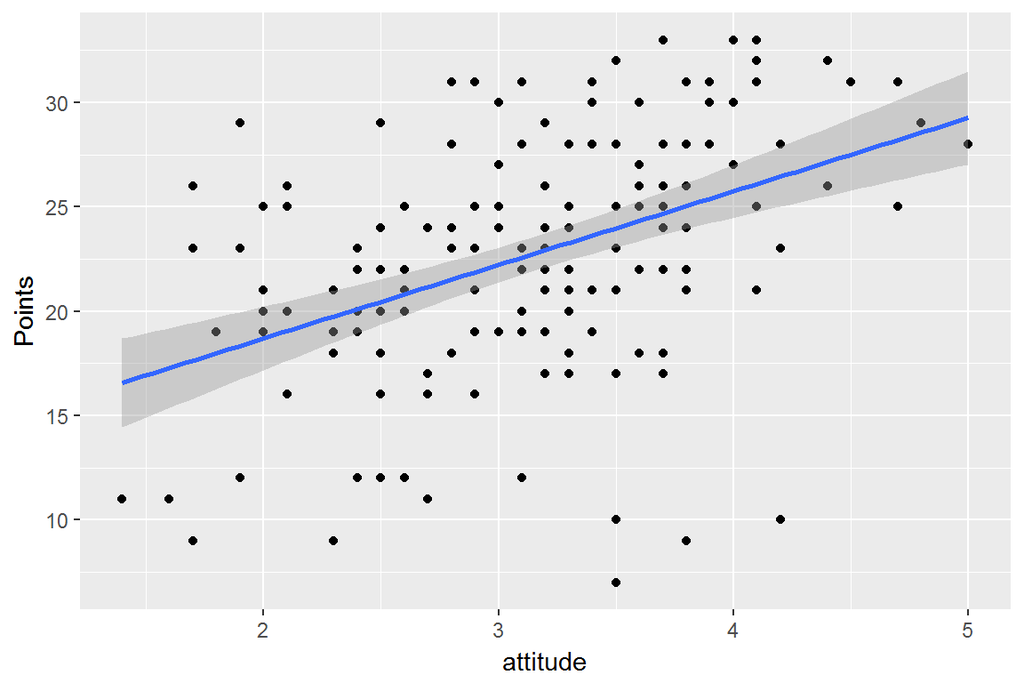

```r
p <- ggplot(l2014, aes(x = attitude, y = Points)) + geom_point() + stat_smooth(method = "lm", formula = y ~ x, size = 1)
p
```

- Model interpretation

- diagnostic plots

Assumptions such as linearity and normally distributed error(with constant variance) can be evaluated using certain plots such as qq plot.

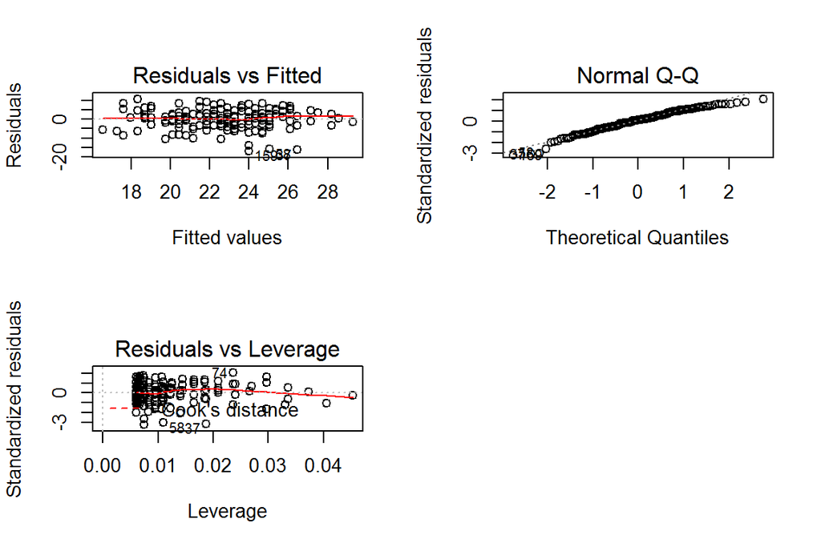

```r
par(mfrow = c(2,2))
plot(point_lm2, which = c(1, 2, 5))
```

The residuals vs fitted values plot doesn’t show any pattern and residual values more or less fall on the straight line on the Q-Q plot. In addition, it doesn’t appear that certain observations have high leverage biasing the model. Therfore our model appears to have satisfied the assumptions made in linear regression model.

## Chapter 3:Logistic Regression and cross validation

In this chapter we will be working with logistic Regression. We will use logistic regression to model the relationship between a binary dependent variable(high_use) and 4 independent variables(failures,absences,sex and freetime)

The dataset we used in this chapter can be found at [alc](https://archive.ics.uci.edu/ml/datasets/Student+Performance).The dataset contains performance of students from two Portugese highschools in the two subjects, Maths and Portugese.

#### Logisitc Regression model

1- reading dataset

```r
alc <- read.table("data/alc.csv",header=T, sep="\t")
```

2- data overview

The data overview was checked using colnames. The dataset contained 35 columns related to student performances in two subjects

```r
colnames(alc)
```

```
##  [1] "school"     "sex"        "age"        "address"    "famsize"
##  [6] "Pstatus"    "Medu"       "Fedu"       "Mjob"       "Fjob"
## [11] "reason"     "nursery"    "internet"   "guardian"   "traveltime"
## [16] "studytime"  "failures"   "schoolsup"  "famsup"     "paid"
## [21] "activities" "higher"     "romantic"   "famrel"     "freetime"
## [26] "goout"      "Dalc"       "Walc"       "health"     "absences"
## [31] "G1"         "G2"         "G3"         "alc_use"    "high_use"
```

3-relationships between high/low alcohol consumption and failures,absences,sex and freetime

Personal hypotheses:

- failures and absences are related to high alcohol consumption
- women have low alcohol consumption than men
- students with more freetime have high alcohol consumption

4- graphical explorations

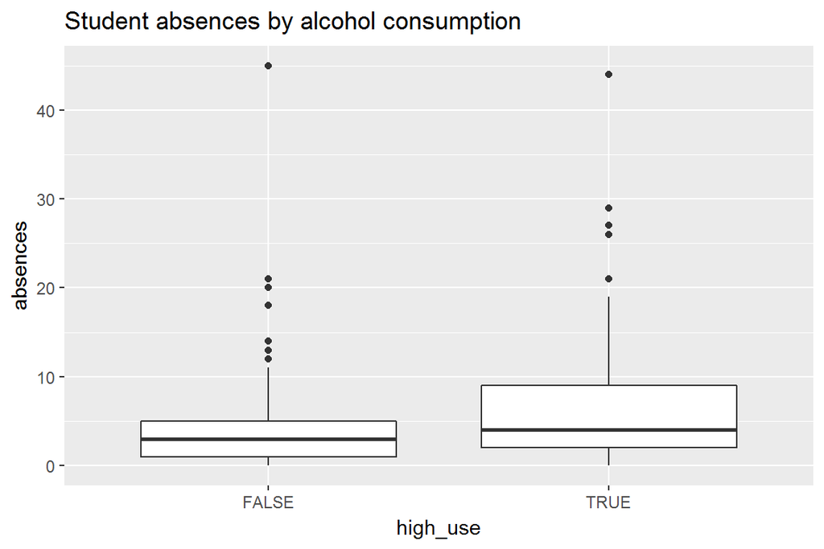

```r
library(dplyr)
library(ggplot2)

# absences vs high_use
g1 <- ggplot(alc, aes(x = high_use, y = absences))
g1 + geom_boxplot() + ylab("absences")+ggtitle("Student absences by alcohol consumption")
```

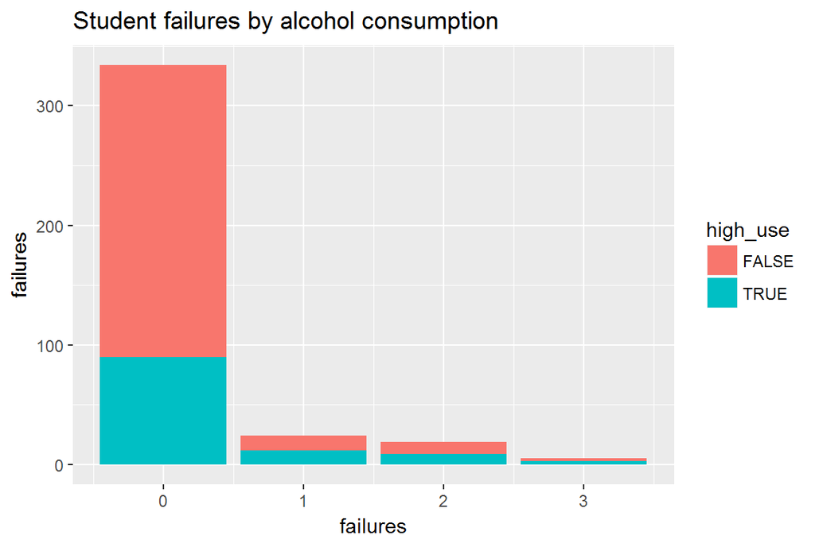

```r
# failures vs high_use
g2 <- ggplot(alc, aes(x = failures, fill = high_use))
g2 + geom_bar() + ylab("failures")+ggtitle("Student failures by alcohol consumption")
```

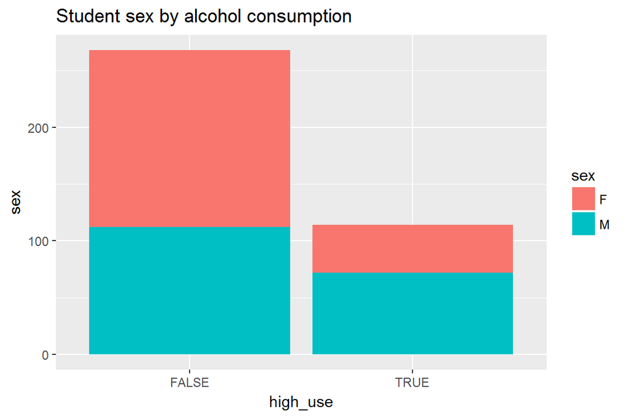

```r
# absences vs high_use
g3 <- ggplot(alc, aes(x = high_use, fill = sex))
g3 + geom_bar() + ylab("sex")+ggtitle("Student sex by alcohol consumption")
```

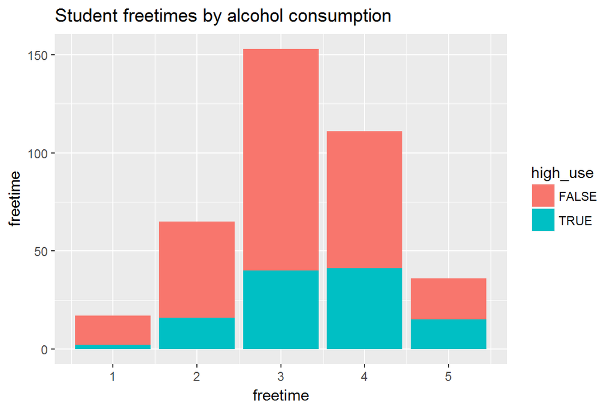

```r
# absences vs high_use
g4 <- ggplot(alc, aes(x = freetime, fill = high_use))
g4 + geom_bar() + ylab("freetime")+ggtitle("Student freetimes by alcohol consumption")
```

The above plots seem to indicate that the personal hypotheses do hold true. But we will need to fit a model to say for sure(i.e. whether or not the relations are statistically significant).

5- Logistic regression model

All the explanantory variables, in agreement with the hypotheses, are statistically significantly related to the dependent variable.So the more the absences and the failures and having more free time and being Male are related to high alcohol consumption (this is seen from the odds ratio, they are all above 1).

```r
m <- glm(high_use ~ failures + absences+sex+freetime, data = alc, family = "binomial")
summary(m)
```

```
##
## Call:
## glm(formula = high_use ~ failures + absences + sex + freetime,
##     family = "binomial", data = alc)
##
## Deviance Residuals:
##     Min       1Q   Median       3Q      Max
## -1.9664  -0.8170  -0.6065   1.0585   2.0330
##
## Coefficients:
##             Estimate Std. Error z value Pr(>|z|)
## (Intercept) -2.75479    0.46053  -5.982 2.21e-09 ***
## failures     0.43004    0.19312   2.227 0.025961 *
## absences     0.09461    0.02280   4.150 3.33e-05 ***
## sexM         0.84223    0.24705   3.409 0.000652 ***
## freetime     0.27453    0.12543   2.189 0.028621 *
## ---
## Signif. codes:  0 '***' 0.001 '**' 0.01 '*' 0.05 '.' 0.1 ' ' 1
##
## (Dispersion parameter for binomial family taken to be 1)
##
##     Null deviance: 465.68  on 381  degrees of freedom
## Residual deviance: 419.50  on 377  degrees of freedom
## AIC: 429.5
##
## Number of Fisher Scoring iterations: 4
```

```r
coef(m)
```

```
## (Intercept)    failures    absences        sexM    freetime
## -2.75478571  0.43003682  0.09460961  0.84223122  0.27453170
```

```r
OR <- coef(m) %>% exp
CI <- confint(m) %>% exp
cbind(OR, CI)
```

```
##                     OR      2.5 %    97.5 %
## (Intercept) 0.06362265 0.02504274 0.1528626
## failures    1.53731413 1.05427814 2.2602725
## absences    1.09922964 1.05343261 1.1522505
## sexM        2.32154106 1.43694673 3.7924512
## freetime    1.31591429 1.03172262 1.6889201
```

6- predictive power of the model

The total proportion of inaccurately classified individuals is equal to 0.2591623 (0.03926702+0.21989529) which is the proportion of wrongly predicted as True when the actual values were False and those wrongly classified as False when their actual values were True. At higher probabilities(>0.5) the predictive power of the model improves(see figure).Compared to simple guessing strategy, it performs better especially in the case where for instance most of the actual values are False but we simply guessed True (the loss function would be higher in the guessing strategy in this case as demonstrated by the loss function).

```r
probabilities <- predict(m, type = "response")

# add the predicted probabilities to 'alc'
alc <- mutate(alc, probability = probabilities)
alc <- mutate(alc, prediction = probability > 0.5)
# cross tabulation
table(high_use = alc$high_use, prediction = alc$prediction)%>%prop.table()%>%addmargins
```

```
##         prediction
## high_use      FALSE       TRUE        Sum
##    FALSE 0.66230366 0.03926702 0.70157068
##    TRUE  0.21989529 0.07853403 0.29842932
##    Sum   0.88219895 0.11780105 1.00000000
```

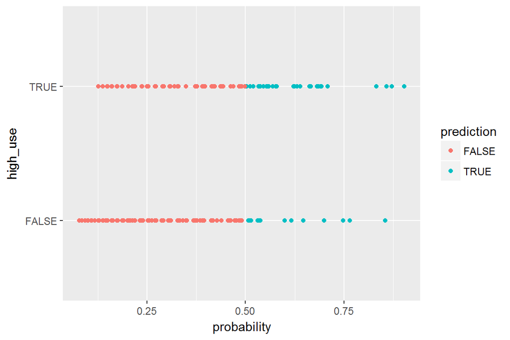

```r
#actual values and predicted values
g <- ggplot(alc, aes(x = probability, y = high_use,col=prediction))

g+geom_point()
```

```r
# compare to simple guessing strategy
loss_func <- function(class, prob) {
  n_wrong <- abs(class - prob) > 0.5
  mean(n_wrong)
}

loss_func(class = alc$high_use, prob = 1)
```

```
## [1] 0.7015707
```

7- cross validation(Bonus)

The 10 fold cross validation doesn’t seem to improve the performance of the model as the error is about the same (~0.26)

```r
library(boot)
cv <- cv.glm(data = alc, cost = loss_func, glmfit = m, K = 10)
cv$delta[1]
```

```
## [1] 0.2696335
```

## Chapter 4: Clustering and classification

In this chapter, we will do classification and clustering using LDA and Kmeans algorithms respectively.

- The dataset(Boston) we will be working with comes with the MASS package and we will load that dataset and check what it contains.

```r
library(MASS)

# loading
data("Boston")

# exploring
dim(Boston)
```

```
## [1] 506  14
```

```r
str(Boston)
```

```
## 'data.frame':    506 obs. of  14 variables:
##  $ crim   : num  0.00632 0.02731 0.02729 0.03237 0.06905 ...
##  $ zn     : num  18 0 0 0 0 0 12.5 12.5 12.5 12.5 ...
##  $ indus  : num  2.31 7.07 7.07 2.18 2.18 2.18 7.87 7.87 7.87 7.87 ...
##  $ chas   : int  0 0 0 0 0 0 0 0 0 0 ...
##  $ nox    : num  0.538 0.469 0.469 0.458 0.458 0.458 0.524 0.524 0.524 0.524 ...
##  $ rm     : num  6.58 6.42 7.18 7 7.15 ...
##  $ age    : num  65.2 78.9 61.1 45.8 54.2 58.7 66.6 96.1 100 85.9 ...
##  $ dis    : num  4.09 4.97 4.97 6.06 6.06 ...
##  $ rad    : int  1 2 2 3 3 3 5 5 5 5 ...
##  $ tax    : num  296 242 242 222 222 222 311 311 311 311 ...
##  $ ptratio: num  15.3 17.8 17.8 18.7 18.7 18.7 15.2 15.2 15.2 15.2 ...
##  $ black  : num  397 397 393 395 397 ...
##  $ lstat  : num  4.98 9.14 4.03 2.94 5.33 ...
##  $ medv   : num  24 21.6 34.7 33.4 36.2 28.7 22.9 27.1 16.5 18.9 ...
```

```r
head(Boston)
```

```
##      crim zn indus chas   nox    rm  age    dis rad tax ptratio  black
## 1 0.00632 18  2.31    0 0.538 6.575 65.2 4.0900   1 296    15.3 396.90
## 2 0.02731  0  7.07    0 0.469 6.421 78.9 4.9671   2 242    17.8 396.90
## 3 0.02729  0  7.07    0 0.469 7.185 61.1 4.9671   2 242    17.8 392.83
## 4 0.03237  0  2.18    0 0.458 6.998 45.8 6.0622   3 222    18.7 394.63
## 5 0.06905  0  2.18    0 0.458 7.147 54.2 6.0622   3 222    18.7 396.90
## 6 0.02985  0  2.18    0 0.458 6.430 58.7 6.0622   3 222    18.7 394.12
##   lstat medv
## 1  4.98 24.0
## 2  9.14 21.6
## 3  4.03 34.7
## 4  2.94 33.4
## 5  5.33 36.2
## 6  5.21 28.7
```

The Boston dataset contains 506 observations with 14 variables that give various information on the housing values in the Boston suburbs such as crime rate.

- looking at the first few records and summarizing the info

```r
head(Boston)
```

```
##      crim zn indus chas   nox    rm  age    dis rad tax ptratio  black
## 1 0.00632 18  2.31    0 0.538 6.575 65.2 4.0900   1 296    15.3 396.90
## 2 0.02731  0  7.07    0 0.469 6.421 78.9 4.9671   2 242    17.8 396.90
## 3 0.02729  0  7.07    0 0.469 7.185 61.1 4.9671   2 242    17.8 392.83
## 4 0.03237  0  2.18    0 0.458 6.998 45.8 6.0622   3 222    18.7 394.63
## 5 0.06905  0  2.18    0 0.458 7.147 54.2 6.0622   3 222    18.7 396.90
## 6 0.02985  0  2.18    0 0.458 6.430 58.7 6.0622   3 222    18.7 394.12
##   lstat medv
## 1  4.98 24.0
## 2  9.14 21.6
## 3  4.03 34.7
## 4  2.94 33.4
## 5  5.33 36.2
## 6  5.21 28.7
```

```r
summary(Boston)
```

```
##       crim                zn             indus            chas
##  Min.   : 0.00632   Min.   :  0.00   Min.   : 0.46   Min.   :0.00000
##  1st Qu.: 0.08204   1st Qu.:  0.00   1st Qu.: 5.19   1st Qu.:0.00000
##  Median : 0.25651   Median :  0.00   Median : 9.69   Median :0.00000
##  Mean   : 3.61352   Mean   : 11.36   Mean   :11.14   Mean   :0.06917
##  3rd Qu.: 3.67708   3rd Qu.: 12.50   3rd Qu.:18.10   3rd Qu.:0.00000
##  Max.   :88.97620   Max.   :100.00   Max.   :27.74   Max.   :1.00000
##       nox               rm             age              dis
##  Min.   :0.3850   Min.   :3.561   Min.   :  2.90   Min.   : 1.130
##  1st Qu.:0.4490   1st Qu.:5.886   1st Qu.: 45.02   1st Qu.: 2.100
##  Median :0.5380   Median :6.208   Median : 77.50   Median : 3.207
##  Mean   :0.5547   Mean   :6.285   Mean   : 68.57   Mean   : 3.795
##  3rd Qu.:0.6240   3rd Qu.:6.623   3rd Qu.: 94.08   3rd Qu.: 5.188
##  Max.   :0.8710   Max.   :8.780   Max.   :100.00   Max.   :12.127
##       rad              tax           ptratio          black
##  Min.   : 1.000   Min.   :187.0   Min.   :12.60   Min.   :  0.32
##  1st Qu.: 4.000   1st Qu.:279.0   1st Qu.:17.40   1st Qu.:375.38
##  Median : 5.000   Median :330.0   Median :19.05   Median :391.44
##  Mean   : 9.549   Mean   :408.2   Mean   :18.46   Mean   :356.67
##  3rd Qu.:24.000   3rd Qu.:666.0   3rd Qu.:20.20   3rd Qu.:396.23
##  Max.   :24.000   Max.   :711.0   Max.   :22.00   Max.   :396.90
##      lstat            medv
##  Min.   : 1.73   Min.   : 5.00
##  1st Qu.: 6.95   1st Qu.:17.02
##  Median :11.36   Median :21.20
##  Mean   :12.65   Mean   :22.53
##  3rd Qu.:16.95   3rd Qu.:25.00
##  Max.   :37.97   Max.   :50.00
```

The range of values in the variable is different (as can be seen from the summary) so before further analysis, some type of scaling is needed. This is done below.

Next we can look at the correlation between the different variables utilizing the cor function and then plotting these correlation coefficients(corrplot)

```r
library(dplyr)
library(corrplot)

cor_matrix<-cor(Boston)

cor_matrix <- cor_matrix %>% round(digits=2)
cor_matrix
```

```
##          crim    zn indus  chas   nox    rm   age   dis   rad   tax
## crim     1.00 -0.20  0.41 -0.06  0.42 -0.22  0.35 -0.38  0.63  0.58
## zn      -0.20  1.00 -0.53 -0.04 -0.52  0.31 -0.57  0.66 -0.31 -0.31
## indus    0.41 -0.53  1.00  0.06  0.76 -0.39  0.64 -0.71  0.60  0.72
## chas    -0.06 -0.04  0.06  1.00  0.09  0.09  0.09 -0.10 -0.01 -0.04
## nox      0.42 -0.52  0.76  0.09  1.00 -0.30  0.73 -0.77  0.61  0.67
## rm      -0.22  0.31 -0.39  0.09 -0.30  1.00 -0.24  0.21 -0.21 -0.29
## age      0.35 -0.57  0.64  0.09  0.73 -0.24  1.00 -0.75  0.46  0.51
## dis     -0.38  0.66 -0.71 -0.10 -0.77  0.21 -0.75  1.00 -0.49 -0.53
## rad      0.63 -0.31  0.60 -0.01  0.61 -0.21  0.46 -0.49  1.00  0.91
## tax      0.58 -0.31  0.72 -0.04  0.67 -0.29  0.51 -0.53  0.91  1.00
## ptratio  0.29 -0.39  0.38 -0.12  0.19 -0.36  0.26 -0.23  0.46  0.46
## black   -0.39  0.18 -0.36  0.05 -0.38  0.13 -0.27  0.29 -0.44 -0.44
## lstat    0.46 -0.41  0.60 -0.05  0.59 -0.61  0.60 -0.50  0.49  0.54
## medv    -0.39  0.36 -0.48  0.18 -0.43  0.70 -0.38  0.25 -0.38 -0.47
##         ptratio black lstat  medv
## crim       0.29 -0.39  0.46 -0.39
## zn        -0.39  0.18 -0.41  0.36
## indus      0.38 -0.36  0.60 -0.48
## chas      -0.12  0.05 -0.05  0.18
## nox        0.19 -0.38  0.59 -0.43
## rm        -0.36  0.13 -0.61  0.70
## age        0.26 -0.27  0.60 -0.38
## dis       -0.23  0.29 -0.50  0.25
## rad        0.46 -0.44  0.49 -0.38
## tax        0.46 -0.44  0.54 -0.47
## ptratio    1.00 -0.18  0.37 -0.51
## black     -0.18  1.00 -0.37  0.33
## lstat      0.37 -0.37  1.00 -0.74
## medv      -0.51  0.33 -0.74  1.00
```

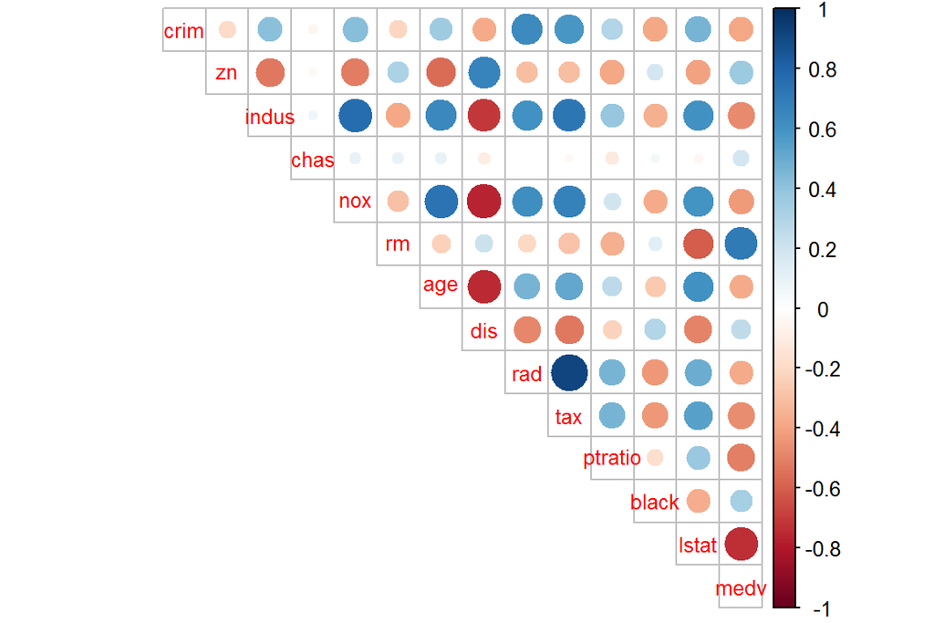

```r
# plot the correlation matrix
corrplot(cor_matrix, method="circle",type="upper",tl.pos = "d",tl.cex = 0.8)
```

From the correlation plot, we can see that the tax and rad variables have strong positive correlation to the crime rate. Strong correlation could be positive or negative.

- scaling the variables

Since the range of values of some variables in the dataset vary widely, we need to standardize the data such that the mean is 0 with unit variance using the scale function (This is just one way of standaridizing, there are also other ways such as making the values fall between certain interval say 0 and 1).

```r
# mean scaling
boston_scaled <- scale(Boston)

summary(boston_scaled)
```

```
##       crim                 zn               indus
##  Min.   :-0.419367   Min.   :-0.48724   Min.   :-1.5563
##  1st Qu.:-0.410563   1st Qu.:-0.48724   1st Qu.:-0.8668
##  Median :-0.390280   Median :-0.48724   Median :-0.2109
##  Mean   : 0.000000   Mean   : 0.00000   Mean   : 0.0000
##  3rd Qu.: 0.007389   3rd Qu.: 0.04872   3rd Qu.: 1.0150
##  Max.   : 9.924110   Max.   : 3.80047   Max.   : 2.4202
##       chas              nox                rm               age
##  Min.   :-0.2723   Min.   :-1.4644   Min.   :-3.8764   Min.   :-2.3331
##  1st Qu.:-0.2723   1st Qu.:-0.9121   1st Qu.:-0.5681   1st Qu.:-0.8366
##  Median :-0.2723   Median :-0.1441   Median :-0.1084   Median : 0.3171
##  Mean   : 0.0000   Mean   : 0.0000   Mean   : 0.0000   Mean   : 0.0000
##  3rd Qu.:-0.2723   3rd Qu.: 0.5981   3rd Qu.: 0.4823   3rd Qu.: 0.9059
##  Max.   : 3.6648   Max.   : 2.7296   Max.   : 3.5515   Max.   : 1.1164
##       dis               rad               tax             ptratio
##  Min.   :-1.2658   Min.   :-0.9819   Min.   :-1.3127   Min.   :-2.7047
##  1st Qu.:-0.8049   1st Qu.:-0.6373   1st Qu.:-0.7668   1st Qu.:-0.4876
##  Median :-0.2790   Median :-0.5225   Median :-0.4642   Median : 0.2746
##  Mean   : 0.0000   Mean   : 0.0000   Mean   : 0.0000   Mean   : 0.0000
##  3rd Qu.: 0.6617   3rd Qu.: 1.6596   3rd Qu.: 1.5294   3rd Qu.: 0.8058
##  Max.   : 3.9566   Max.   : 1.6596   Max.   : 1.7964   Max.   : 1.6372
##      black             lstat              medv
##  Min.   :-3.9033   Min.   :-1.5296   Min.   :-1.9063
##  1st Qu.: 0.2049   1st Qu.:-0.7986   1st Qu.:-0.5989
##  Median : 0.3808   Median :-0.1811   Median :-0.1449
##  Mean   : 0.0000   Mean   : 0.0000   Mean   : 0.0000
##  3rd Qu.: 0.4332   3rd Qu.: 0.6024   3rd Qu.: 0.2683
##  Max.   : 0.4406   Max.   : 3.5453   Max.   : 2.9865
```

```r
class(boston_scaled)
```

```
## [1] "matrix"
```

```r
# scaled data(boston_scaled) is a matrix so we are changin to a data frame
boston_scaled <- as.data.frame(boston_scaled)
```

The scaling resulted in variables with a mean of 0, and a standard deviation of 1.

Next, we categorize the crime data in to 4 classes (low, med_low,med_high and high) by using the quantiles of the values.

```r
# create the quantile bins
bins <- quantile(boston_scaled$crim)
bins
```

```
##           0%          25%          50%          75%         100%
## -0.419366929 -0.410563278 -0.390280295  0.007389247  9.924109610
```

```r
# assign names to the bins and cut the data based on those bins which are the quantiles
crime <- cut(boston_scaled$crim, breaks = bins, include.lowest = TRUE,labels=c("low","med_low","med_high","high"))

#  remove the original crime data and replace it with the one we just created, so the crime values are now the classes
boston_scaled <- dplyr::select(boston_scaled, -crim)

boston_scaled <- data.frame(boston_scaled, crime)
```

Then we sample from the scaled data, to make 80% of the data as a training set and the rest 20% testing set (i.e to test how accurately our methods classify the crime and we know what the real classes of our test data are)

```r
# we obtain the number of rows to use for sampling
n <- nrow(boston_scaled)

# sample 80 percent of the data, i.e. you have the row indices here
ind <- sample(n,  size = n * 0.8)

# based on those indices we choose our training set
train <- boston_scaled[ind,]

# the rest is the test data
test <- boston_scaled[-ind,]

# we know the correct classes from our test set
correct_classes <- test$crime

# remove the crime classes, so that we replace them with the predicted values from the next steps
test <- dplyr::select(test, -crime)
```

- LDA for classification

We fit an LDA model on the crime variable(against all other variables)

```r
# lda
lda.fit <- lda(crime ~ . , data = train)

lda.fit
```

```
## Call:
## lda(crime ~ ., data = train)
##
## Prior probabilities of groups:
##       low   med_low  med_high      high
## 0.2351485 0.2574257 0.2599010 0.2475248
##
## Group means:
##                   zn      indus        chas        nox         rm
## low       0.89836833 -0.9251388 -0.14799959 -0.8869726  0.4623276
## med_low  -0.09000825 -0.2816139 -0.08304540 -0.5705109 -0.1405456
## med_high -0.37126774  0.1250362  0.21512144  0.3626993  0.2078676
## high     -0.48724019  1.0171519 -0.03610305  1.0576234 -0.3990571
##                 age        dis        rad        tax    ptratio      black
## low      -0.8650684  0.8396710 -0.6832698 -0.7358385 -0.3966342  0.3739931
## med_low  -0.3088285  0.3794895 -0.5467789 -0.4816711 -0.0940488  0.3187348
## med_high  0.4100091 -0.3508717 -0.3879497 -0.3099445 -0.3208308  0.1114095
## high      0.8024516 -0.8486907  1.6377820  1.5138081  0.7803736 -0.7593410
##                lstat        medv
## low      -0.76275113  0.51490281
## med_low  -0.10550922 -0.02625393
## med_high -0.08707741  0.26711859
## high      0.82188576 -0.65616375
##
## Coefficients of linear discriminants:
##                  LD1          LD2          LD3
## zn       0.082434816  0.681495768 -0.929169522
## indus    0.014340840 -0.223115125  0.434397073
## chas    -0.073680272 -0.103191220 -0.009412151
## nox      0.445921345 -0.825254130 -1.310696447
## rm      -0.079440266 -0.088013389 -0.218247339
## age      0.277488319 -0.329739013 -0.083669967
## dis     -0.040071414 -0.279096067  0.213987008
## rad      2.960607245  0.953723697 -0.061307290
## tax      0.009563279 -0.047501243  0.462187511
## ptratio  0.128972723  0.021009097 -0.380323700
## black   -0.127372810  0.007925389  0.138881881
## lstat    0.197641414 -0.139334943  0.441724537
## medv     0.200952129 -0.378832029 -0.152146471
##
## Proportion of trace:
##    LD1    LD2    LD3
## 0.9432 0.0412 0.0156
```

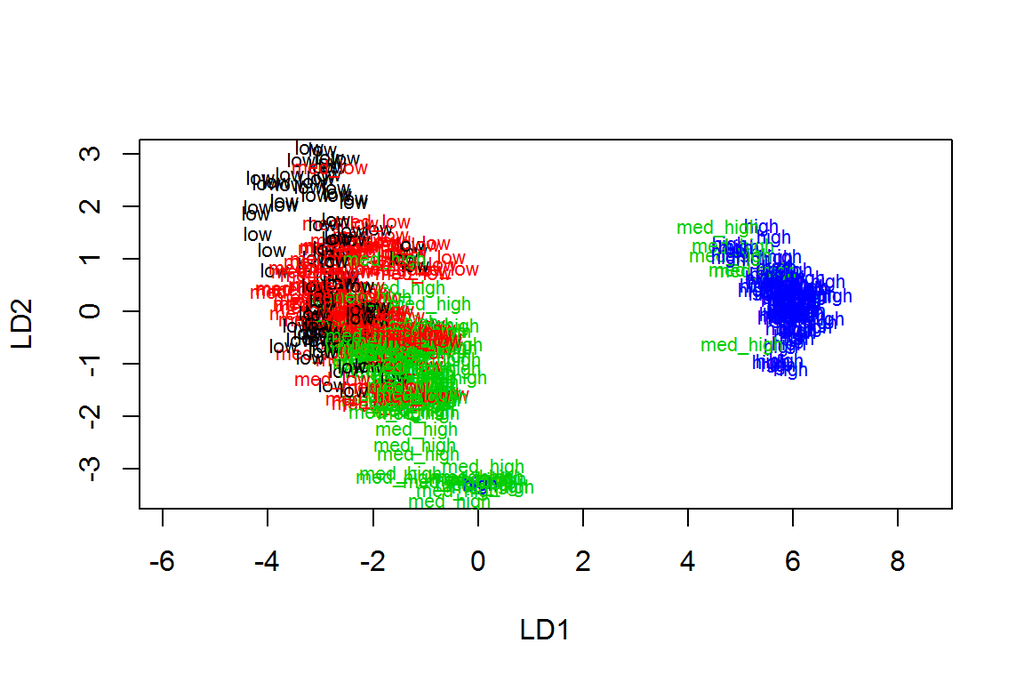

```r
# plot the lda results
classes <- as.numeric(train$crime)
plot(lda.fit, dimen = 2,col = classes,pch=classes)
```

- Predicting crime

Now it is time to predict crime and check it against the true values we have in our test set.Cross tabulations are a convenient way to check the number of correctly/incorrectly classified features.

```r
lda.pred <- predict(lda.fit, newdata = test)

# cross tabulate the results
table(correct = correct_classes, predicted = lda.pred$class)
```

```
##           predicted
## correct    low med_low med_high high
##   low       20       9        3    0
##   med_low    5      13        4    0
##   med_high   1       6       14    0
##   high       0       0        0   27
```

The predictor seems to underpeform for the med_low and med_high classes (which might actually be hard to separate with a linear discriminator). On the other hand, it has made correct predictions for the high (and also relatively the low classes).

- Kmeans clustering

In the Kmeans clustering, finding the optiaml K is one of the key goals. In this exercies we have utilized the with in sum of squares to identify the K that will minimize this error. We start with k=3 but later we determine the optimal K to be 2 (after checking k 1:10) and we rerun our kmeans clustering with this value.

```r
library(ggplot2)

data('Boston')
boston_scaled <- scale(Boston)

# euclidean distance matrix
dist_eu <- dist(boston_scaled)
summary(dist_eu)
```

```
##    Min. 1st Qu.  Median    Mean 3rd Qu.    Max.
##  0.1343  3.4625  4.8241  4.9111  6.1863 14.3970
```

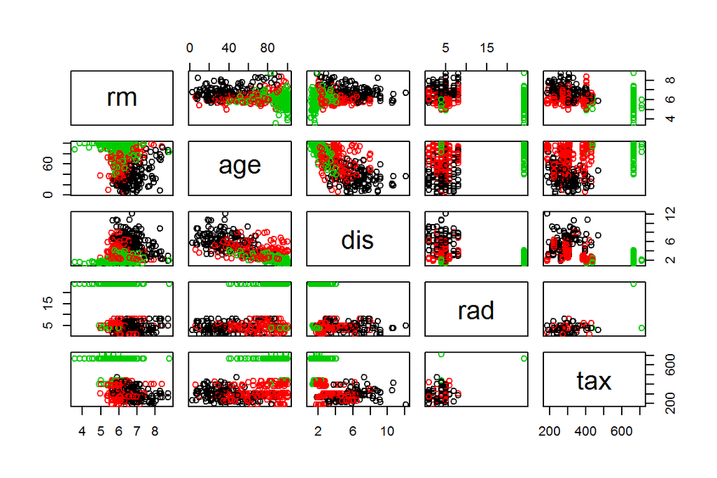

```r
# k-means clustering
km <-kmeans(boston_scaled, centers = 3)

pairs(Boston[6:10], col = km$cluster)
```

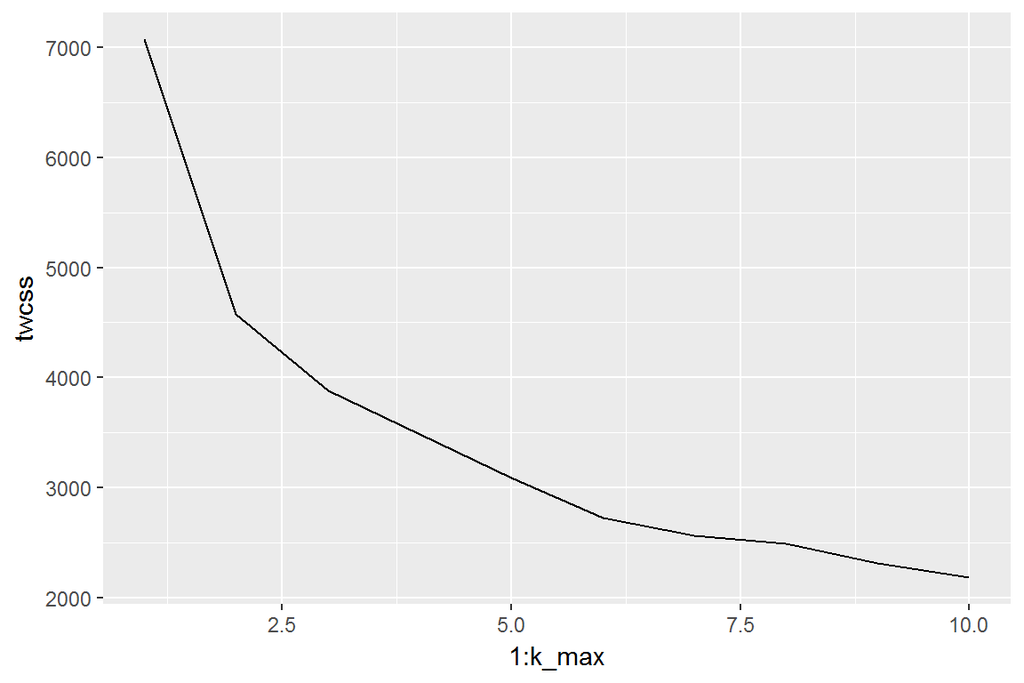

```r
# determine the number of clusters
k_max <- 10

# calculate the total within sum of squares
twcss <- sapply(1:k_max, function(k){kmeans(boston_scaled, k)$tot.withinss})

# visualize the results
qplot(x = 1:k_max, y = twcss, geom = 'line')
```

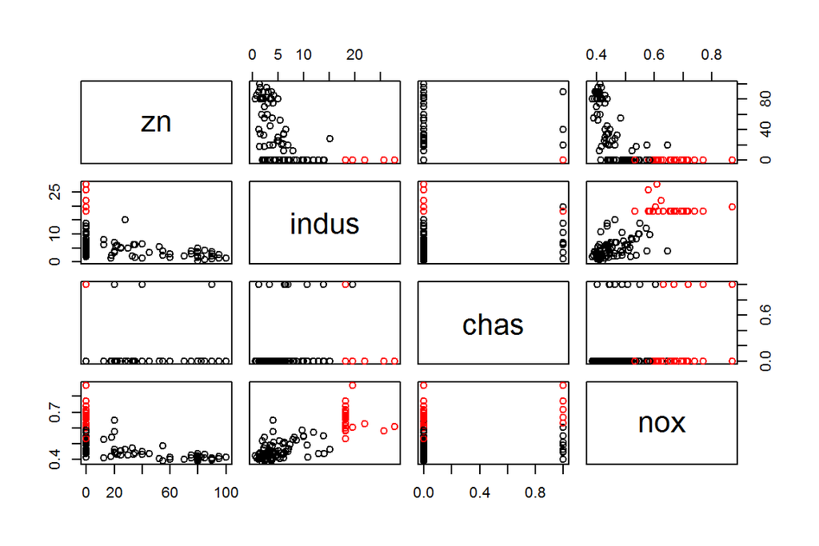

```r
# k-means clustering
km2 <-kmeans(boston_scaled, centers = 2)
pairs(Boston[2:5], col = km2$cluster)
```

We see a sharp drop at k~2, so we have chosen this to be the optimal k. However, it might still be good to check other k values.

- Bonus

We can do LDA on the Boston dataset using k-means assigned clusters as the target variable. We run kmeans on the scaled data (boston_scaled) with k = 3. We then add the cluster result to the data. Then we fit LDA as follows:

```r
set.seed(80)
# k-means clustering
km2 <-kmeans(boston_scaled, centers = 3,iter.max=20)

boston_scaled <- data.frame(boston_scaled, cluster=km2$cluster)

# linear discriminant analysis
ldaWithKm <- lda(cluster ~ . , data = boston_scaled)
ldaWithKm
```

```
## Call:
## lda(cluster ~ ., data = boston_scaled)
##
## Prior probabilities of groups:
##         1         2         3
## 0.4268775 0.2470356 0.3260870
##
## Group means:
##         crim         zn      indus         chas        nox         rm
## 1 -0.3788713 -0.3578148 -0.2879024  0.001080671 -0.3709704 -0.2328004
## 2 -0.3989700  1.2614609 -0.9791535 -0.020354653 -0.8573235  1.0090468
## 3  0.7982270 -0.4872402  1.1186734  0.014005495  1.1351215 -0.4596725
##           age        dis        rad        tax     ptratio      black
## 1 -0.05427143  0.1034286 -0.5857564 -0.5951053  0.01241316  0.2805140
## 2 -0.96130713  0.9497716 -0.5867985 -0.6709807 -0.80239137  0.3552363
## 3  0.79930921 -0.8549214  1.2113527  1.2873657  0.59162230 -0.6363367
##        lstat        medv
## 1 -0.1047617 -0.09820229
## 2 -0.9571271  1.06668290
## 3  0.8622388 -0.67953738
##
## Coefficients of linear discriminants:
##                 LD1         LD2
## crim    -0.03206338 -0.19094456
## zn       0.02935900 -1.07677218
## indus    0.63347352 -0.09917524
## chas     0.02460719  0.10009606
## nox      1.11749317 -0.75995105
## rm      -0.18841682 -0.57360135
## age     -0.12983139  0.47226685
## dis      0.04493809 -0.34585958
## rad      0.67004295 -0.08584353
## tax      1.03992455 -0.58075025
## ptratio  0.25864960 -0.02605279
## black   -0.01657236  0.01975686
## lstat    0.17365575 -0.41704235
## medv    -0.06819126 -0.79098605
##
## Proportion of trace:
##    LD1    LD2
## 0.8506 0.1494
```

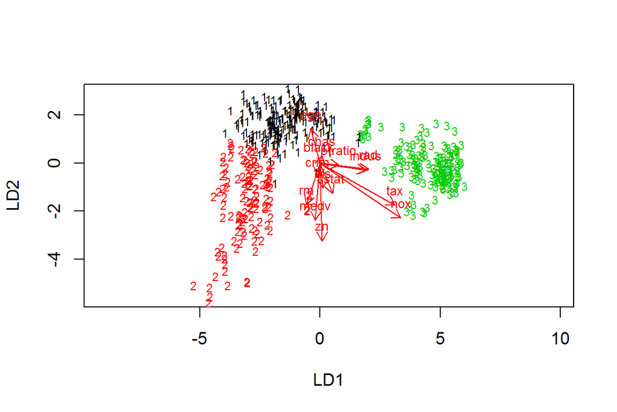

```r
# the function for lda biplot arrows: function copied from datacamp exercise
lda.arrows <- function(x, myscale = 1, arrow_heads = 0.1, color = "red", tex = 0.75, choices = c(1,2)){
  heads <- coef(x)
  arrows(x0 = 0, y0 = 0,
         x1 = myscale * heads[,choices[1]],
         y1 = myscale * heads[,choices[2]], col=color, length = arrow_heads)
  text(myscale * heads[,choices], labels = row.names(heads),
       cex = tex, col=color, pos=3)
}

# plot the lda results
plot(ldaWithKm, dimen = 2,col = boston_scaled$cluster)
lda.arrows(ldaWithKm, myscale = 3)
```

Cluster 1 is influenced most by variable age, cluster 2 by variables such as zn and rm, and cluster 3 by variables such as indus,tax and nox.

#### Data wrangling for next week data

The R script utilized for wrangling next week’s data can be found at (https://github.com/rigbe-ods/IODS-project/blob/master/data/create_human.R). The human dataset after the data wrangling can be found (https://github.com/rigbe-ods/IODS-project/blob/master/data/human.txt)

## Chapter 5: Dimensionality reduction techniques

In this chapter, we will look at ways on how we can reduce high dimensionality by employing components that explain the variability of the data.

- We will be working with the Human Development Index data which contains information about health, knowledge and standard of living such as maternal mortality rate, the ratio of females to males with at leaset secondary education etc.We will load that dataset and check what it contains.

```r
# loading
human = read.table("data/human.txt", sep="\t")

# exploring
dim(human)
```

```
## [1] 155   8
```

```r
str(human)
```

```
## 'data.frame':    155 obs. of  8 variables:
##  $ FemMaleEdu  : num  1.007 0.997 0.983 0.989 0.969 ...
##  $ FemMaleLabor: num  0.891 0.819 0.825 0.884 0.829 ...
##  $ EduExp      : num  17.5 20.2 15.8 18.7 17.9 16.5 18.6 16.5 15.9 19.2 ...
##  $ LifeExp     : num  81.6 82.4 83 80.2 81.6 80.9 80.9 79.1 82 81.8 ...
##  $ Gni         : int  64992 42261 56431 44025 45435 43919 39568 52947 42155 32689 ...
##  $ MaMortalityR: int  4 6 6 5 6 7 9 28 11 8 ...
##  $ AdBirthRate : num  7.8 12.1 1.9 5.1 6.2 3.8 8.2 31 14.5 25.3 ...
##  $ ParPer      : num  39.6 30.5 28.5 38 36.9 36.9 19.9 19.4 28.2 31.4 ...
```

```r
head(human)
```

```
##             FemMaleEdu FemMaleLabor EduExp LifeExp   Gni MaMortalityR
## Norway       1.0072389    0.8908297   17.5    81.6 64992            4
## Australia    0.9968288    0.8189415   20.2    82.4 42261            6
## Switzerland  0.9834369    0.8251001   15.8    83.0 56431            6
## Denmark      0.9886128    0.8840361   18.7    80.2 44025            5
## Netherlands  0.9690608    0.8286119   17.9    81.6 45435            6
## Germany      0.9927835    0.8072289   16.5    80.9 43919            7
##             AdBirthRate ParPer
## Norway              7.8   39.6
## Australia          12.1   30.5
## Switzerland         1.9   28.5
## Denmark             5.1   38.0
## Netherlands         6.2   36.9
## Germany             3.8   36.9
```

The human dataset contains 155 observations with 8 variables

- a graphical overview of the data and summaries

```r
library(GGally)

summary(human)
```

```
##    FemMaleEdu      FemMaleLabor        EduExp         LifeExp
##  Min.   :0.1717   Min.   :0.1857   Min.   : 5.40   Min.   :49.00
##  1st Qu.:0.7264   1st Qu.:0.5984   1st Qu.:11.25   1st Qu.:66.30
##  Median :0.9375   Median :0.7535   Median :13.50   Median :74.20
##  Mean   :0.8529   Mean   :0.7074   Mean   :13.18   Mean   :71.65
##  3rd Qu.:0.9968   3rd Qu.:0.8535   3rd Qu.:15.20   3rd Qu.:77.25
##  Max.   :1.4967   Max.   :1.0380   Max.   :20.20   Max.   :83.50
##       Gni          MaMortalityR     AdBirthRate         ParPer
##  Min.   :   581   Min.   :   1.0   Min.   :  0.60   Min.   : 0.00
##  1st Qu.:  4198   1st Qu.:  11.5   1st Qu.: 12.65   1st Qu.:12.40
##  Median : 12040   Median :  49.0   Median : 33.60   Median :19.30
##  Mean   : 17628   Mean   : 149.1   Mean   : 47.16   Mean   :20.91
##  3rd Qu.: 24512   3rd Qu.: 190.0   3rd Qu.: 71.95   3rd Qu.:27.95
##  Max.   :123124   Max.   :1100.0   Max.   :204.80   Max.   :57.50
```

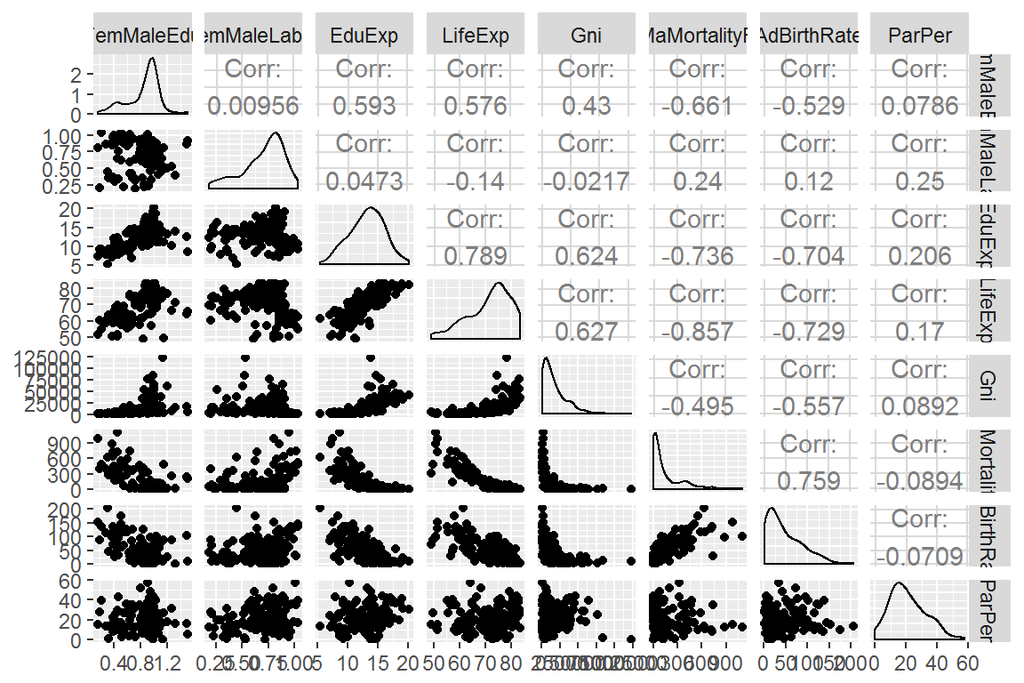

```r
ggpairs(human)
```

The ratio of female to male with at least secondary education is bigger than the ratio of female to male in the labour force. The percentage of women in parliament is ~20% which is very low (it is not even 50/50).

The maternal mortality rate and Life expectancy are highly negatively correlated as expected(-0.857) while expected education in years is highly positively correlated to life expectancy(0.789).The GNI is right skewed(most of the countires studied have low GNI)

- perform pca

```r
# perform principal component analysis (with the SVD method)
pca_human <- prcomp(human)

# to see the variability captured by the PCs,
summary(pca_human)
```

```
## Importance of components%s:
##                              PC1      PC2   PC3   PC4   PC5   PC6    PC7
## Standard deviation     1.854e+04 185.5219 25.19 11.45 3.766 1.566 0.1912
## Proportion of Variance 9.999e-01   0.0001  0.00  0.00 0.000 0.000 0.0000
## Cumulative Proportion  9.999e-01   1.0000  1.00  1.00 1.000 1.000 1.0000
##                           PC8
## Standard deviation     0.1591
## Proportion of Variance 0.0000
## Cumulative Proportion  1.0000
```

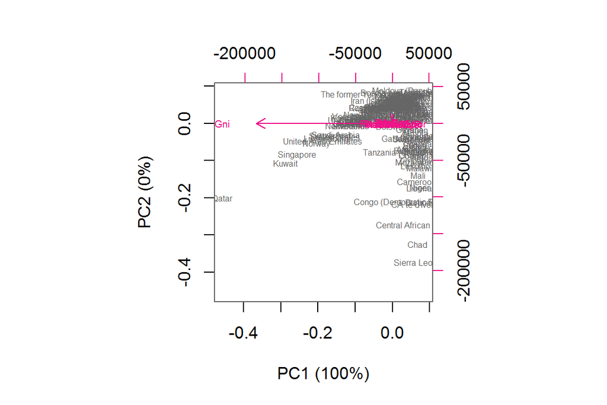

Figure:PCA unstandardized data. The first principal component is mainly affected by GNI which has high variability

```r
# plot the biplot of the pca results

pca_pr <- round(100*summary(pca_human)$importance[2, ], digits = 1)
pc_lab <- paste0(names(pca_pr), " (", pca_pr, "%)")

# biplot of the new pca results
biplot(pca_human, choices = 1:2,cex = c(0.5, 0.6),col = c("grey40", "deeppink2"),xlab = pc_lab[1], ylab = pc_lab[2])
```

The first PC captures almost all of the variability (~99.99%) and the first two components together capture 100% of the variability (this is possibly due to the lack of standardization which biases our pca).

- PCA on the standardized human dataset and interpretation

Since the range of values of some variables in the dataset vary widely, we need to standardize the data such that the mean is 0 with unit variance using the scale function.

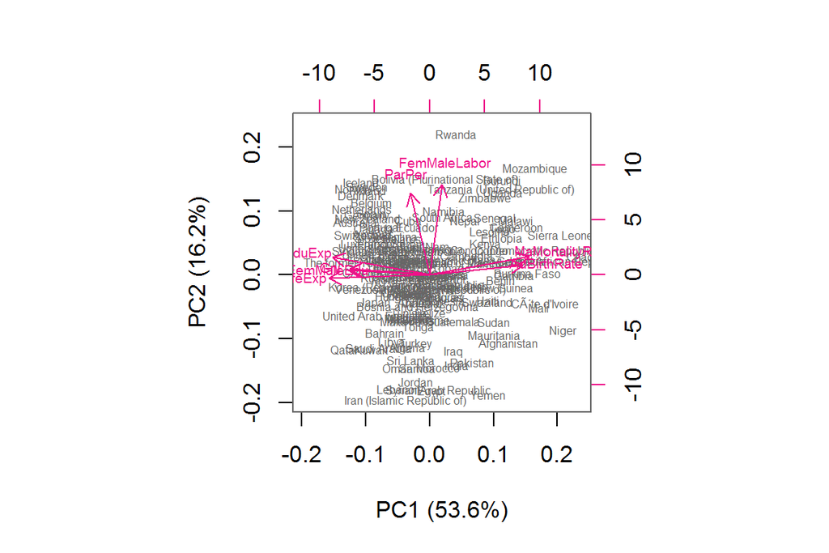

Figure:PCA standardized data. Variables realted to education, and variables related to health contribute more to the first principal component while variable related to labour such as labor force and parliament participation contribue more to the second pc.

```r
# scaling the human data
human_std <- scale(human)

# pca on the standardized version
pca_humanstd <- prcomp(human_std)

pca_pr <- round(100*summary(pca_humanstd)$importance[2, ], digits = 1)
pc_lab <- paste0(names(pca_pr), " (", pca_pr, "%)")

# biplot of the new pca results
biplot(pca_humanstd, choices = 1:2,cex = c(0.5, 0.6),col = c("grey40", "deeppink2"),xlab = pc_lab[1], ylab = pc_lab[2])
```

The scaling changed the pca results, i.e. the proportion of variance explained by the first pc is now only ~54% and that of the second pc is ~16% (so the first two components explain ~70% of the variability).Standardization removes the bias introduced by variables that contain a wide range of values

- Multiple Correspondence Analysis on the tea data

```r
# loading the tea dataset
library(FactoMineR)
library(dplyr)
library(tidyr)
library(ggplot2)
data("tea")

# explore the tea dataset, the tea dataset contains 300 observations and 36 variables
str(tea)
```

```
## 'data.frame':    300 obs. of  36 variables:
##  $ breakfast       : Factor w/ 2 levels "breakfast","Not.breakfast": 1 1 2 2 1 2 1 2 1 1 ...
##  $ tea.time        : Factor w/ 2 levels "Not.tea time",..: 1 1 2 1 1 1 2 2 2 1 ...
##  $ evening         : Factor w/ 2 levels "evening","Not.evening": 2 2 1 2 1 2 2 1 2 1 ...
##  $ lunch           : Factor w/ 2 levels "lunch","Not.lunch": 2 2 2 2 2 2 2 2 2 2 ...
##  $ dinner          : Factor w/ 2 levels "dinner","Not.dinner": 2 2 1 1 2 1 2 2 2 2 ...
##  $ always          : Factor w/ 2 levels "always","Not.always": 2 2 2 2 1 2 2 2 2 2 ...
##  $ home            : Factor w/ 2 levels "home","Not.home": 1 1 1 1 1 1 1 1 1 1 ...
##  $ work            : Factor w/ 2 levels "Not.work","work": 1 1 2 1 1 1 1 1 1 1 ...
##  $ tearoom         : Factor w/ 2 levels "Not.tearoom",..: 1 1 1 1 1 1 1 1 1 2 ...
##  $ friends         : Factor w/ 2 levels "friends","Not.friends": 2 2 1 2 2 2 1 2 2 2 ...
##  $ resto           : Factor w/ 2 levels "Not.resto","resto": 1 1 2 1 1 1 1 1 1 1 ...
##  $ pub             : Factor w/ 2 levels "Not.pub","pub": 1 1 1 1 1 1 1 1 1 1 ...
##  $ Tea             : Factor w/ 3 levels "black","Earl Grey",..: 1 1 2 2 2 2 2 1 2 1 ...
##  $ How             : Factor w/ 4 levels "alone","lemon",..: 1 3 1 1 1 1 1 3 3 1 ...
```

[output cut: 22 more lines]

```r
summary(tea)
```

```
##          breakfast           tea.time          evening          lunch
##  breakfast    :144   Not.tea time:131   evening    :103   lunch    : 44
##  Not.breakfast:156   tea time    :169   Not.evening:197   Not.lunch:256
##
##
##
##
##
##         dinner           always          home           work
##  dinner    : 21   always    :103   home    :291   Not.work:213
##  Not.dinner:279   Not.always:197   Not.home:  9   work    : 87
##
##
##
##
##
##         tearoom           friends          resto          pub
##  Not.tearoom:242   friends    :196   Not.resto:221   Not.pub:237
##  tearoom    : 58   Not.friends:104   resto    : 79   pub    : 63
##
##
##
##
##
##         Tea         How           sugar                     how
##  black    : 74   alone:195   No.sugar:155   tea bag           :170
##  Earl Grey:193   lemon: 33   sugar   :145   tea bag+unpackaged: 94
##  green    : 33   milk : 63                  unpackaged        : 36
##                  other:  9
##
##
##
##                   where                 price          age        sex
##  chain store         :192   p_branded      : 95   Min.   :15.00   F:178
##  chain store+tea shop: 78   p_cheap        :  7   1st Qu.:23.00   M:122
##  tea shop            : 30   p_private label: 21   Median :32.00
##                             p_unknown      : 12   Mean   :37.05
##                             p_upscale      : 53   3rd Qu.:48.00
##                             p_variable     :112   Max.   :90.00
##
```

[output cut: 25 more lines]

```
##  feminine    :129   Not.sophisticated: 85   No.slimming:255
##  Not.feminine:171   sophisticated    :215   slimming   : 45
##
##
##
##
##
##         exciting          relaxing              effect.on.health
##  exciting   :116   No.relaxing:113   effect on health   : 66
##  No.exciting:184   relaxing   :187   No.effect on health:234
##
##
##
##
##
```